# Project: Communicate Data Findings

## Part 3 - Exploration Result

## Dataset Overview

### Subject

The master data set consists of two groups of bike-sharing rides for months July 2019 and July 2020.

We have selected these two months in order to assess the impatct of CoViD19 on Lyft-BayWheels bike rentals.

More precisely and by looking at CoViD19 cases in the Bay Area, we have selected the month of July 2020 as reference, for it is the month with the highest number of cases available.

We have then selected data for July 2019 as counterpart. To select the same month allows us to avoid biases related to (for instance) season, scheduled events, tourism, etc...

[figure not shown]

(Source: [DataSF](https://data.sfgov.org/stories/s/dak2-gvuj) )

### Structure

| Col.Nr. | Column Name | Variable Type |
| --- | --- | --- |
| 0 | duration | Cardinal |
| 1 | start_time | Cardinal |
| 2 | end_time | Cardinal |
| 3 | start_station_id | Categorical |
| 4 | start_station_name | Categorical |
| 5 | start_station_latitude | Cardinal |
| 6 | start_station_longitude | Cardinal |
| 7 | end_station_id | Categorical |
| 8 | end_station_name | Categorical |
| 9 | end_station_latitude | Cardinal |
| 10 | end_station_longitude | Cardinal |
| 11 | user_type | Categorical |
| 12 | distance_km | Cardinal |

The dataset consists of 13 columns with straightforward meaning.

'duration', 'start_time', and 'end_time' have been set as dtype datetime/timedelta for easier exploration and manipulation. 'duration' shows now just non-negative values.

Station-IDs have been transformed into Int64 - this allows for both, keeping NaNs as np.nan and avoiding decimals.

'user_type' values have been standardized to 'member' and 'casual'.

Station data have been cleaned. We have now unique ID-name correspondence and each geographic coordinate is linked with a unique station ID (if given).

We have decided to keep records with missing station-IDs and station-names, for this issue affects a high amount of data - drop them may bias our analysis. We will exclude NaNs, when and if needeed.

In last position, we have added the geodesic distance in km between start/end geographic coordinates.

## Exploratory Data Analysis

We aim at analyzing differences in data patterns and statistics that can be reconducted to the current pandemic situation, but also for insights in general.

More precisely and linked to the data structure, we tried to answer to these questions:

1. Does the two months under analysis share the same trend of number of rides per day, distance, or duration?
2. Is there a difference in station usage (frequency of use) in 2019 and in 2020?
3. What is the relation between trip distance and average duration?
4. Do 'casual' users an 'members' differ w.r.t. duration and distance?
5. What is the relation between hour of day and day of week?
6. Does Geospatial visualization give us more information on duration and distance?

### Question 1

Does the two months under analysis share the same trend of number of rides per day, distance, or duration?

```python
print('# of rides in July 2019: ', m2019count,'\n# of rides in July 2020: ', m2020count,
      '\nPercentual change : ', "%.2f"%(pct_chg))
```

```
# of rides in July 2019:  258102
# of rides in July 2020:  154712
Percentual change :  -40.06
```

Overall, the # of rides in July 2020 dropped of about 40% w.r.t. the same period in 2019.

##### Rides per Calendar Day

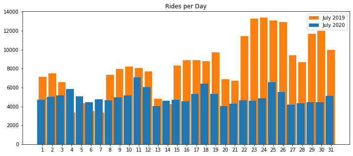

```python
base_color1 = sb.color_palette()[0]
base_color2 = sb.color_palette()[1]
fig = plt.figure()
ax = fig.add_subplot(111)
data = rides_per_day_2020['count']
idx = rides_per_day_2020.day.values.tolist()
width = np.min(np.diff(idx))/6
data2 = rides_per_day_2019['count']
ax.bar(idx, data2, label='July 2019', color=base_color2)
ax.bar(idx - width, data, label='July 2020', color=base_color1)
plt.xticks(np.arange(1, 31+1, 1))
plt.gcf().set_size_inches(12,5)
plt.title('Rides per Day')
#plt.xlabel('July')
#plt.ylabel('count')
plt.legend()
plt.show();

#Ref.s:
# 1- https://stackoverflow.com/questions/10369681/how-to-plot-bar-graphs-with-same-x-coordinates-side-by-side-dodged
# 2- https://pythonbasics.org/matplotlib-bar-chart/
```

The pandemic has had a major effect on BayWheels rides. 2020 shows a stable trend around 4K and 6K rides per day, whereas 2019 displays an upward trend with a peak above 13K rides per day.

We can note a marked cyclicality. Therefore, we will analyze the # of rides per day of week.

##### Rides per Weekday

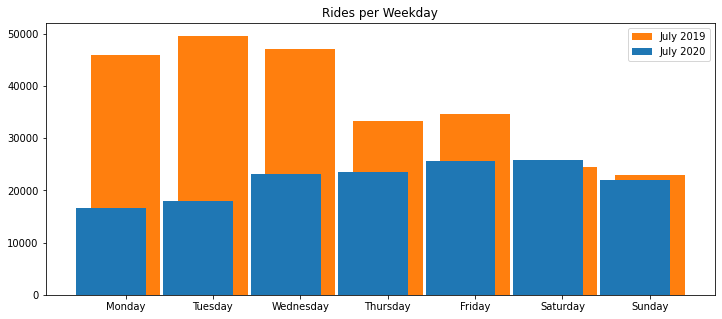

```python
base_color1 = sb.color_palette()[0]
base_color2 = sb.color_palette()[1]
fig = plt.figure()
ax = fig.add_subplot(111)
data = rides_per_weekday_2020['count']
idx = rides_per_weekday_2020.weekday.values.tolist()
width = np.min(np.diff(idx))/3
width = np.min(np.diff(idx))/6
data2 = rides_per_weekday_2019['count']
ax.bar(idx, data2, label='July 2019', color=base_color2)
ax.bar(idx - width, data, label='July 2020', color=base_color1)
plt.xticks(np.arange(0, 6+1, 1))
plt.gcf().set_size_inches(12,5)
plt.title('Rides per Weekday')
#plt.xlabel('July')
#plt.ylabel('count')
plt.legend()
ax=plt.gca()
ax.set_xticklabels(['Monday', 'Tuesday','Wednesday','Thursday','Friday', 'Saturday','Sunday'])
plt.show();
```

We can see that the drop has been more marked during work days, and decreases during the week. Weekend rides show no effect.

##### Distance per Calendar Day

```python
print('Average distance in July 2019: ', "%.2f"%(m2019_avg_dist),'\nAverage distance in July 2020: ', "%.2f"%(m2020_avg_dist),
      '\nPercentual change : ', "%.2f"%(pct_chg))
```

```
Average distance in July 2019:  1.72
Average distance in July 2020:  2.42
Percentual change :  40.77
```

Although the # of rides in July 2020 has dropped, their average distance increased of about 40% w.r.t. the same period in 2019.

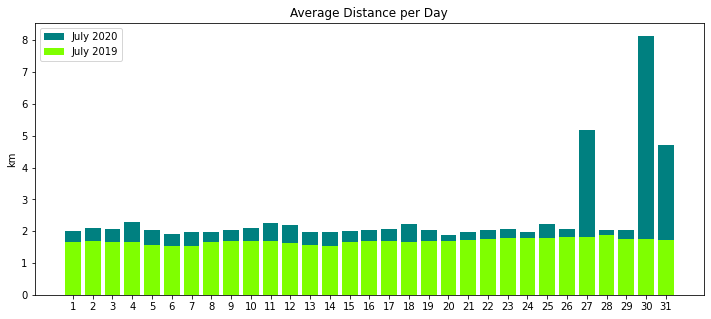

```python
base_color1 = 'teal'
base_color2 = 'chartreuse'
data = mean_per_day_2020['mean']
plt.bar(mean_per_day_2020.day.values.tolist(), data, label='July 2020', color=base_color1)
data2 = mean_per_day_2019['mean']
plt.bar(mean_per_day_2019.day.values.tolist(), data2, label='July 2019', color=base_color2)
plt.xticks(np.arange(1, 31+1, 1))
plt.gcf().set_size_inches(12,5)
plt.title('Average Distance per Day')
#plt.xlabel('July')
plt.ylabel('km')
plt.legend()
plt.show();

#Ref.: https://pythonbasics.org/matplotlib-bar-chart/
```

Generally, 2020 registers a 40%-higher av. distance, w.r.t. 2019. From the graph above, we can see that av. distance in 2020 is indeed higher throughout the whole period.

However, this increase is not equally distributed among days. The average distance follows a common trend in both years for the most days in the dataset, but 2020 shows higher spikes in three of the last five days of the month.

For July 2020 is the month among Bay Wheels data where CoViD19 infections increased more rapidly, we can guess that these spykes are due to more occasional users using the bike-sharing service, in order to avoid public means of transportation (fear of contagion). This may be in line with decreasing overall rides and increasing av. distance, if indeed bike riding has been prefered to travelling by bus.

Spykes may also be due to some public event, like critical mass, or bike tours, for instance. However, we would then expect peaks in the # of rides as well - we do not see that.

##### Distance per Week Day

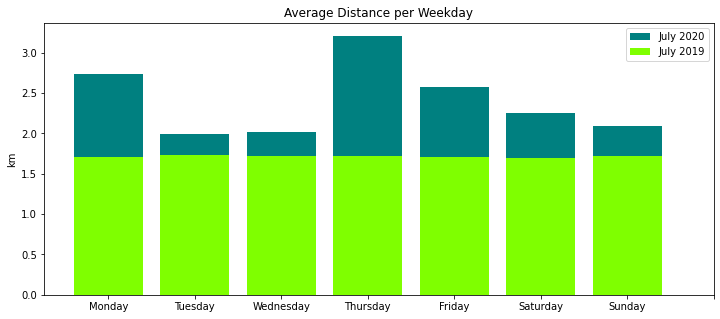

```python
base_color1 = 'teal'
base_color2 = 'chartreuse'
data = mean_per_weekday_2020['mean']
plt.bar(mean_per_weekday_2020.weekday.values.tolist(), data, label='July 2020', color=base_color1)
data2 = mean_per_weekday_2019['mean']
plt.bar(mean_per_weekday_2019.weekday.values.tolist(), data2, label='July 2019', color=base_color2)
plt.xticks(np.arange(0, 7+1, 1))
plt.gcf().set_size_inches(12,5)
plt.title('Average Distance per Weekday')
#plt.xlabel('Weekday')
plt.ylabel('km')
plt.legend()
ax=plt.gca()
ax.set_xticklabels(['Monday', 'Tuesday','Wednesday','Thursday','Friday', 'Saturday','Sunday'])
plt.show();
```

Av. distance is higher in every week day. We should not rely on these peaks, for they are most probably biased by high-frequency days (July 27th is indeed monday...).

#### Average Duration

```python
print('Average duraiton in July 2019: ', "%.2f min"%(m2019_avg_dur),'\nAverage duration in July 2020: ', "%.2f min"%(m2020_avg_dur),
      '\nPercentual change : ', "%.2f"%(pct_chg))
```

```
Average duraiton in July 2019:  14.04 min
Average duration in July 2020:  24.56 min
Percentual change :  74.96
```

Although the # of rides in July 2020 has dropped, their duation has increased of about 75% w.r.t. the same period in 2019.

##### Duration per Calendar Day

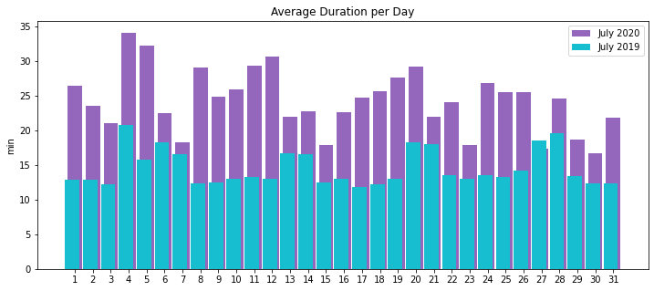

```python
base_color1 = sb.color_palette()[4]
base_color2 = sb.color_palette()[9]
fig = plt.figure()
ax = fig.add_subplot(111)
data = duration_per_day_2020['mean']
idx = duration_per_day_2020.day.values.tolist()
width = np.min(np.diff(idx))/7
data2 = duration_per_day_2019['mean']
ax.bar(idx , data, label='July 2020', color=base_color1)
ax.bar(idx - width, data2, label='July 2019', color=base_color2)
plt.xticks(np.arange(1, 31+1, 1))
plt.gcf().set_size_inches(12,5)
plt.title('Average Duration per Day')
#plt.xlabel('July')
plt.ylabel('min')
plt.legend()
plt.show();
```

From the graph above, we can see that av. duration in 2020 is indeed higher throughout (almost) the whole period.

Days in 2020 show a higher volatility than days in 2019, although the two series look more or less stable.

##### Duration per Week Day

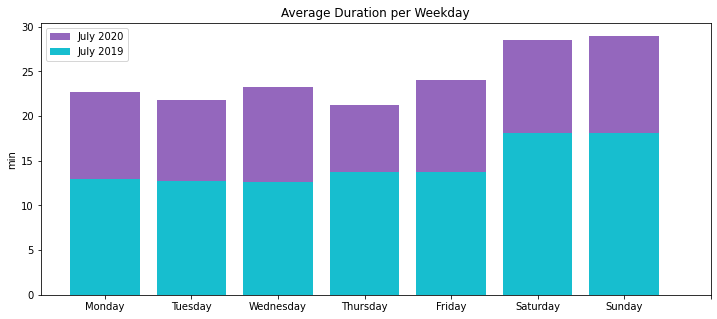

```python
base_color1 = sb.color_palette()[4]
base_color2 = sb.color_palette()[9]
data = duration_per_weekday_2020['mean']
plt.bar(duration_per_weekday_2020.weekday.values.tolist(), data, label='July 2020', color=base_color1)
data2 = duration_per_weekday_2019['mean']
plt.bar(duration_per_weekday_2019.weekday.values.tolist(), data2, label='July 2019', color=base_color2)
plt.xticks(np.arange(0, 7+1, 1))
plt.gcf().set_size_inches(12,5)
plt.title('Average Duration per Weekday')
#plt.xlabel('Weekday')
plt.ylabel('min')
plt.legend()
ax=plt.gca()
ax.set_xticklabels(['Monday', 'Tuesday','Wednesday','Thursday','Friday', 'Saturday','Sunday'])
plt.show();
```

Av. duration is higher in every week day in 2020. Duration increase looks constant for every weekday and year.

#### User Type

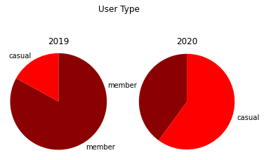

```python
plt.suptitle('User Type')
colrs={'casual':'red' , 'member':'darkred'}
# left plot
plt.subplot(1, 2, 1)
plt.title('2019')
sorted_counts = m2019['user_type'].value_counts()
colrs19 = [colrs[x] for x in sorted_counts.index]
plt.pie(sorted_counts, labels = sorted_counts.index.tolist(), colors=colrs19, startangle = 90, counterclock = False);
plt.axis('square');

# right plt
plt.subplot(1, 2, 2)
plt.title('2020')
sorted_counts = m2020['user_type'].value_counts()
colrs20 = [colrs[x] for x in sorted_counts.index]
plt.pie(sorted_counts, labels = sorted_counts.index.tolist(), colors=colrs20, startangle = 90, counterclock = False);
plt.axis('square')
plt.show();
```

```python
pct_chg=((92845-43959)/43959)*100
print('Casual user pct. change: ', "%.2f"%(pct_chg))
```

```
Casual user pct. change:  111.21
```

```python
pct_chg=((61867-214143)/214143)*100
print('Member user pct. change: ', "%.2f"%(pct_chg))
```

```
Member user pct. change:  -71.11
```

While overall usage dropped by 40% in 2020 w.r.t. 2019, member usage dropped more than 70%, but casual users have more than doubled.

Overall in July 2020, we have:

- less rides per day (especially on work days);
- higher distance;
- higher duration;
- more casual users (both, in absolute terms and w.r.t. members);
- less member usage.

### Question 2

Is there a difference in station usage (frequency of use) in 2019 and in 2020?

```python
stations.head(10)
```

|  | station_name | 2019 | 2020 | change_pct |
| --- | --- | --- | --- | --- |
| 0 | San Francisco Caltrain Station 2 (Townsend St... | 5018 | <NA> | <NA> |
| 1 | Berry St at 4th St | 4410 | 877 | -80.1134 |
| 2 | San Francisco Ferry Building (Harry Bridges Pl... | 3881 | 723 | -81.3708 |
| 3 | Market St at 10th St | 3348 | 1469 | -56.1231 |
| 4 | Montgomery St BART Station (Market St at 2nd St) | 3305 | 672 | -79.6672 |
| 5 | Market St at Steuart St | 3092 | 835 | -72.9948 |
| 6 | Powell St BART Station (Market St at 4th St) | 3029 | 1219 | -59.7557 |
| 7 | Howard St at Beale St | 2902 | 353 | -87.836 |
| 8 | Powell St BART Station (Market St at 5th St) | 2606 | <NA> | <NA> |
| 9 | The Embarcadero at Sansome St | 2467 | 519 | -78.9623 |

##### Top Percentual Change

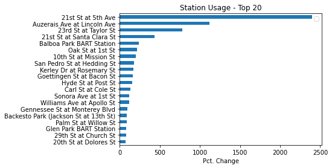

```python
stations.dropna().sort_values(by='change_pct', ascending=True).tail(20).plot(x='station_name',y='change_pct', kind='barh');
plt.title('Station Usage - Top 20')
plt.legend('')
plt.ylabel('')
plt.xlabel('Pct. Change');
```

We can see that most stations with the highest increase lay near a park.

##### Bottom Percentual Change

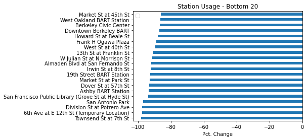

```python
stations.dropna().sort_values(by='change_pct', ascending=True).head(20).plot(x='station_name',y='change_pct', kind='barh');
plt.title('Station Usage - Bottom 20');
plt.legend('');
plt.ylabel('');
plt.xlabel('Pct. Change');
```

On the contrary, we find other public places among stations with the highest decrease (e.g. pulic library, BART stations).

#### Distribution of Station Usage

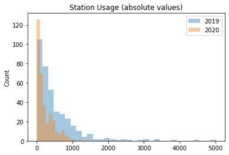

```python
sb.distplot(stations['2019'].dropna(), kde = False, label='2019');
sb.distplot(stations['2020'].dropna(), kde = False, label='2020');
plt.title('Station Usage (absolute values)')
plt.xlabel('')
plt.ylabel('Count')
#plt.grid(True)
#plt.xlim([-101, 300]);
plt.legend();
```

The distribution of station usage in 2020 is more concentrated around the first bin an has less mass in the tail.

Only stations that registered a low number of bike rentals are more frequent in 2020 than in 2019, while stations have registered less rentals in 2020 in general.

We can inspect the percental change as well.

#### Distribution of Percentual Change in Station Usage

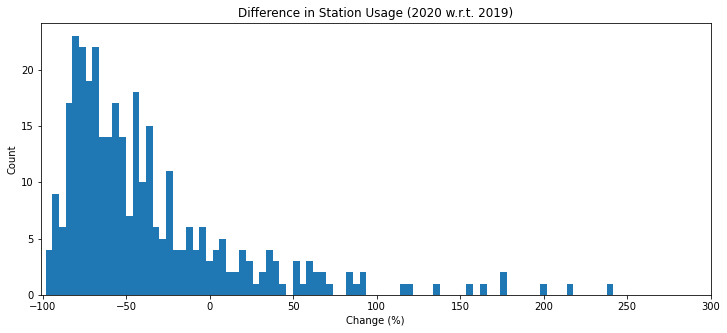

```python
station_noNan = stations.dropna().copy()
bin_edges = np.arange(station_noNan['change_pct'].min(), station_noNan['change_pct'].max(), 4)
plt.gcf().set_size_inches(12,5)
plt.hist(data = station_noNan, x = 'change_pct', bins = bin_edges)
plt.title('Difference in Station Usage (2020 w.r.t. 2019)')
plt.xlabel('Change (%)')
plt.ylabel('Count')
#plt.grid(True)
plt.xlim([-101, 300]);#3300]);
```

Here we can see in detail that most of the mass of station-usage change corresponds indeed to negative values.

Overall, the most stations registered a decrease of usage in july 2020, w.r.t. the same period in 2019.

We have found out that stations with the highest increase lay often near a park, while there are public places and train stations among those with a sharp decrease.

Moreover, sations with a low number of bike rentals are more frequent in 2020 than in 2019, while stations have registered less rentals in 2020 in general.

### Question 3

What is the relation between trip distance and average duration?

#### Duration vs. Distance in 2019

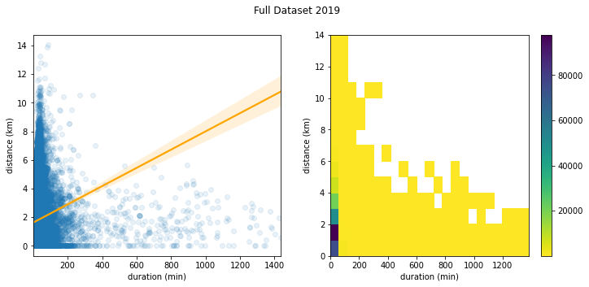

```python
plt.figure(figsize = [12, 5])
plt.suptitle('Full Dataset 2019')
# left plot: scatterplot of discrete data with jitter and transparency
plt.subplot(1, 2, 1)
sb.regplot(data = m2019_noDistOutl, x = 'duration_min', y = 'distance_km', \
           fit_reg = True, scatter_kws = {'alpha' : 1/10}, line_kws={"color": "orange"})
plt.xlabel('duration (min)')
plt.ylabel('distance (km)')

# right plot: heat map with bin edges between values
plt.subplot(1, 2, 2)
bins_x = np.arange(0, m2019_noDistOutl['duration_min'].max(), 60)
bins_y = np.arange(0, m2019_noDistOutl['distance_km'].max(), 1)
plt.hist2d(data = m2019_noDistOutl, x = 'duration_min', y = 'distance_km',
           bins = [bins_x, bins_y],cmap = 'viridis_r', cmin = 1)#, cmax=)
plt.xlabel('duration (min)')
plt.ylabel('distance (km)')
plt.colorbar();
```

The scatter plot (left) shows that distance and duration are directly proportional.

Just by looking at the points, it looks like:

- bikes that are rented for longer time are returned within 6 km radius, while
- bikes used for longer trips are returned earlier.

Nevertheless in the heat map (right), we see a high concentration of points for distance <= 4km and duration <= 50 min (ca.).

We will now inspect this portion of data (distance <= 4km and duration <=30 min).

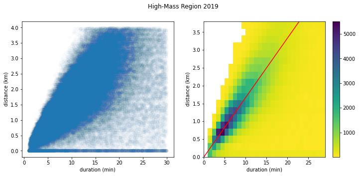

```python
plt.figure(figsize = [12, 5])
plt.suptitle('High-Mass Region 2019')
# left plot: scatterplot of discrete data with jitter and transparency
plt.subplot(1, 2, 1)

sb.regplot(data = m2019_noDistOutl_4km_30min, x = 'duration_min', y = 'distance_km', fit_reg = False, \
           scatter_kws = {'alpha' : 1/100})
plt.xlabel('duration (min)')
plt.ylabel('distance (km)')

# right plot: heat map with bin edges between values
plt.subplot(1, 2, 2)
bins_x = np.arange(0, m2019_noDistOutl_4km_30min['duration_min'].max(), 1)
bins_y = np.arange(0, m2019_noDistOutl_4km_30min['distance_km'].max(), 0.2)
plt.hist2d(data = m2019_noDistOutl_4km_30min, x = 'duration_min', y = 'distance_km',
           bins = [bins_x, bins_y],cmap = 'viridis_r', cmin = 1)#, cmax=)
x=np.linspace(0,30,6)
y=np.arange(len(x))
plt.plot(x,y, color='red')
plt.xlabel('duration (min)')
plt.ylabel('distance (km)')

plt.colorbar();

#Ref.: https://www.machinelearningplus.com/plots/matplotlib-line-plot/
```

By zooming onto the more concentrated region of the graph, we can note a positive relation between duration and distance.

The Heat Map suggests a linear relation that corresponds to ca. 6 min. per km (i.e. 10 km p.h., depicted by the red line).

Of course, this measure cannot be directly interpreted as travel speed, for distance has been calculated as geodesic distance between two points.

If we consider the whole distribution mass, we can also see that the regression line (in orange in the previous scatter plot) has a much flatter slope.

##### Duration vs. Distance in 2020

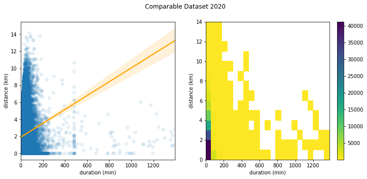

```python
plt.figure(figsize = [12, 5])
plt.suptitle('Comparable Dataset 2020')
# left plot: scatterplot of discrete data with jitter and transparency
plt.subplot(1, 2, 1)
sb.regplot(data = m2020_noDistOutl, x = 'duration_min', y = 'distance_km', \
           fit_reg = True, scatter_kws = {'alpha' : 1/10}, line_kws={"color": "orange"})
plt.xlabel('duration (min)')
plt.ylabel('distance (km)')


# right plot: heat map with bin edges between values
plt.subplot(1, 2, 2)
bins_x = np.arange(0, m2020_noDistOutl['duration_min'].max(), 60)
bins_y = np.arange(0, m2020_noDistOutl['distance_km'].max(), 1)
plt.hist2d(data = m2020_noDistOutl, x = 'duration_min', y = 'distance_km',
           bins = [bins_x, bins_y],cmap = 'viridis_r', cmin = 1)#, cmax=)
plt.xlabel('duration (min)')
plt.ylabel('distance (km)')
plt.colorbar();
```

The scatter plot (left) for 2020 shows a similar distribution of points to 2019. The regression line still shows a positive relation betweeen distance and duration.

The heat map (right) shows a way lower number of rides in the high-mass region w.r.t. 2019.

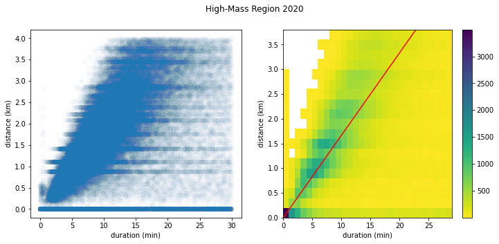

```python
plt.figure(figsize = [12, 5])
plt.suptitle('High-Mass Region 2020')
# left plot: scatterplot of discrete data with jitter and transparency
plt.subplot(1, 2, 1)
sb.regplot(data = m2020_noDistOutl_4km_30min, x = 'duration_min', y = 'distance_km', fit_reg = False, \
           scatter_kws = {'alpha' : 1/100})

plt.xlabel('duration (min)')
plt.ylabel('distance (km)')

# right plot: heat map with bin edges between values
plt.subplot(1, 2, 2)
#plt.title('High-Mass Region')
bins_x = np.arange(0, m2020_noDistOutl_4km_30min['duration_min'].max(), 1)
bins_y = np.arange(0, m2020_noDistOutl_4km_30min['distance_km'].max(), 0.2)
plt.hist2d(data = m2020_noDistOutl_4km_30min, x = 'duration_min', y = 'distance_km',
           bins = [bins_x, bins_y],cmap = 'viridis_r', cmin = 1)#, cmax=)
x=np.linspace(0,30,6)
y=np.arange(len(x))
plt.plot(x,y, color='red')
plt.xlabel('duration (min)')
plt.ylabel('distance (km)')
plt.colorbar();
```

Within the 'high-mass' region, the distribution of points (left) and the heat map graph (right) look similar to those for 2019.

However and in accordance with the previous graph, the heat map shows a way lower number of rides even in the high-mass region w.r.t. 2019.

#### Recap

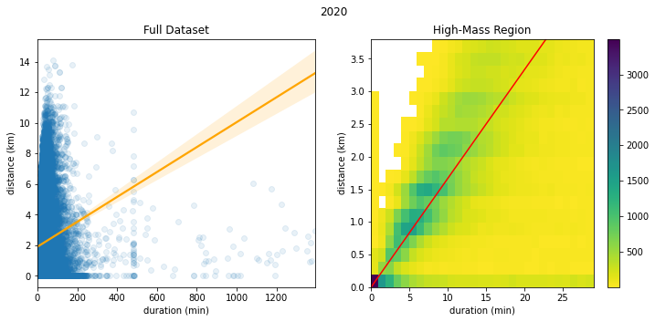

```python
plt.figure(figsize = [12, 5])
plt.suptitle('2020')
# left plot: scatterplot of discrete data with jitter and transparency
plt.subplot(1, 2, 1)
plt.title('Full Dataset')
sb.regplot(data = m2020_noDistOutl, x = 'duration_min', y = 'distance_km', \
           fit_reg = True, scatter_kws = {'alpha' : 1/10}, line_kws={"color": "orange"})
plt.xlabel('duration (min)')
plt.ylabel('distance (km)')

# right plot: heat map with bin edges between values
plt.subplot(1, 2, 2)
plt.title('High-Mass Region')
bins_x = np.arange(0, m2020_noDistOutl_4km_30min['duration_min'].max(), 1)
bins_y = np.arange(0, m2020_noDistOutl_4km_30min['distance_km'].max(), 0.2)
plt.hist2d(data = m2020_noDistOutl_4km_30min, x = 'duration_min', y = 'distance_km',
           bins = [bins_x, bins_y],cmap = 'viridis_r', cmin = 1)#, cmax=)
x=np.linspace(0,30,6)
y=np.arange(len(x))
plt.plot(x,y, color='red')
plt.xlabel('duration (min)')
plt.ylabel('distance (km)')
plt.colorbar();
```

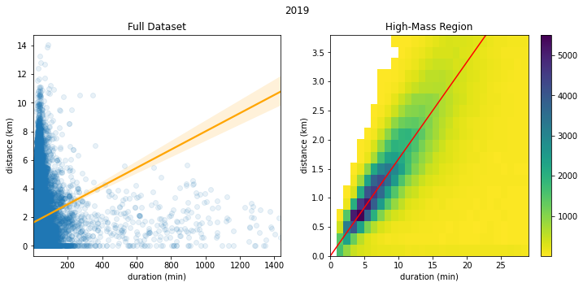

```python
plt.figure(figsize = [12, 5])
plt.suptitle('2019')
# left plot: scatterplot of discrete data with jitter and transparency
plt.subplot(1, 2, 1)

sb.regplot(data = m2019_noDistOutl, x = 'duration_min', y = 'distance_km', \
           fit_reg = True, scatter_kws = {'alpha' : 1/10}, line_kws={"color": "orange"})
plt.xlabel('duration (min)')
plt.ylabel('distance (km)')
plt.title('Full Dataset')

# right plot: heat map with bin edges between values
plt.subplot(1, 2, 2)
bins_x = np.arange(0, m2019_noDistOutl_4km_30min['duration_min'].max(), 1)
bins_y = np.arange(0, m2019_noDistOutl_4km_30min['distance_km'].max(), 0.2)
plt.hist2d(data = m2019_noDistOutl_4km_30min, x = 'duration_min', y = 'distance_km',
           bins = [bins_x, bins_y],cmap = 'viridis_r', cmin = 1)#, cmax=)
x=np.linspace(0,30,6)
y=np.arange(len(x))
plt.plot(x,y, color='red')
plt.xlabel('duration (min)')
plt.ylabel('distance (km)')
plt.title('High-Mass Region')

plt.colorbar();
```

The relation between duration and distance is positive in both, July 2019 and in July 2020.

We have found a high-mass region of the graph, where this relation is clearly visible from the data.

The heat map for the high-mass region suggests a linear relation that corresonds to ca. 6 min. per km (i.e. 10 km p.h., depicted by the red line).

Of course, this measure cannot be directly interpreted as travel speed, for distance has been calculated as geodesic distance between two points.

If we consider the whole distribution mass, we can also see that the regression line (in orange) has a much flatter slope.

The heat maps for 2020 show a way lower number of rides (also in the high-mass region) w.r.t. 2019.

### Question 4

Do 'casual' users an 'members' differ w.r.t. duration and distance?

#### Duration

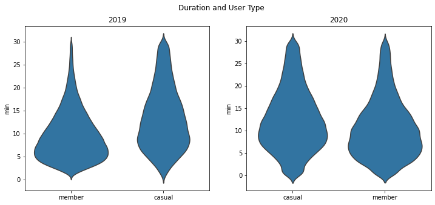

```python
plt.figure(figsize = [12, 5])
plt.suptitle('Duration and User Type')
plt.subplot(1, 2, 1)
plt.title('2019')
base_color = sb.color_palette()[0]
sb.violinplot(data = m2019_noDistOutl_4km_30min.dropna(), x = 'user_type', y = 'duration_min', \
              color = base_color, inner = None)
plt.xlabel('')
plt.ylabel('min');
plt.subplot(1, 2, 2)
plt.title('2020')
#base_color = sb.color_palette()[0]
sb.violinplot(data = m2020_noDistOutl_4km_30min.dropna(), x = 'user_type', y = 'duration_min', \
              color = base_color, inner = None)
plt.xlabel('')
plt.ylabel('min');
```

The violin plots here above show a higher average duration for both user types in 2020.

We can note a gain in distribution mass for both user types in 2020, while this effect is more visible for the casual user-type.

#### Distance

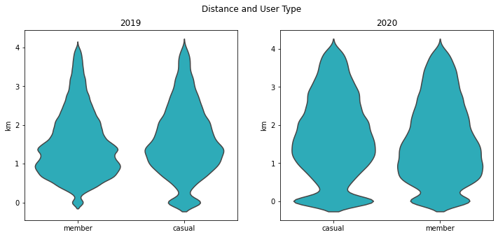

```python
plt.figure(figsize = [12, 5])
plt.suptitle('Distance and User Type')
plt.subplot(1, 2, 1)
plt.title('2019')
base_color = sb.color_palette()[9]
sb.violinplot(data = m2019_noDistOutl_4km_30min.dropna(), x = 'user_type', y = 'distance_km', \
              color = base_color, inner = None)
plt.xlabel('')
plt.ylabel('km');
plt.subplot(1, 2, 2)
plt.title('2020')
#base_color = sb.color_palette()[0]
sb.violinplot(data = m2020_noDistOutl_4km_30min.dropna(), x = 'user_type', y = 'distance_km', \
              color = base_color, inner = None)
plt.xlabel('')
plt.ylabel('km');
```

Concerning the av. distance, we see an even more consistent increase in distribution mass for the two user types in 2020. This is mostly visible in the upper region of the distributions, as well as on the bottom.

### Question 5

What is the relation between hour of day and day of week?

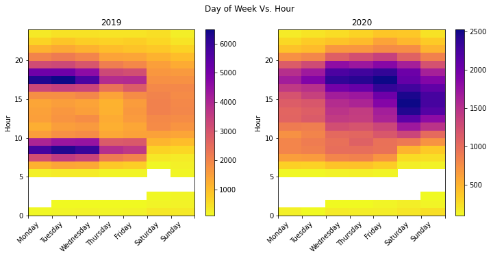

```python
plt.figure(figsize = [12, 5])
plt.suptitle('Day of Week Vs. Hour')
plt.subplot(1, 2, 1)
bins_x = np.arange(0, 7.1, 1)
bins_y = np.arange(0, 24.1, 1)
plt.hist2d(data = m19, x = 'day_of_week', y = 'hour',
           bins = [bins_x, bins_y], cmap = 'plasma_r', cmin = 100)
plt.xlabel('')
plt.ylabel('Hour')
plt.title('2019')
ax=plt.gca()
ax.set_xticklabels(['Monday', 'Tuesday','Wednesday','Thursday','Friday', 'Saturday','Sunday'], rotation=45);
plt.colorbar();
plt.subplot(1, 2, 2)
plt.hist2d(data = m20, x = 'day_of_week', y = 'hour',
           bins = [bins_x, bins_y], cmap = 'plasma_r', cmin = 100)
plt.xlabel('')
plt.ylabel('Hour')
plt.title('2020')
ax=plt.gca()
ax.set_xticklabels(['Monday', 'Tuesday','Wednesday','Thursday','Friday', 'Saturday','Sunday'], rotation=45);
plt.colorbar();
```

While in 2019 we can clearly see a 'commuting' pattern during the week (morning and evening), this patterns is not that clear in 2020. Morning commuting seems to have not been taking place anymore in July 2020, while a clearer pattern of 'free-time' rides appears in the evening hours or during the weekend.

On Friday, Saturday and Sunday this change is more visible.

The overall number of rides per hour is drastically reduced in 2020, w.r.t. 2019.

### Question 6

Does geospatial visualization give us more information on duration and distance?

#### Duration

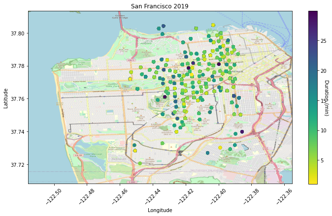

```python
m19_lat_long_sf = m2019_noDistOutl_4km_30min.query('(start_station_latitude > 37.7083)&(start_station_latitude <= 37.8133)&(start_station_longitude <=-122.3554)&(start_station_longitude >=-122.5158)')
BBox = (-122.5158,   -122.3554,  37.7083, 37.8133)
fig, ax = plt.subplots(figsize = (12,12))
pos1 = ax.scatter(data=m19_lat_long_sf.dropna(), \
                           y='start_station_latitude', x='start_station_longitude', c='duration_min', cmap='viridis_r' )
mymap = plt.imread('sfmap.png')
plt.xticks(rotation=45)
ax.set_xlim(BBox[0],BBox[1])
ax.set_ylim(BBox[2],BBox[3])
pos = ax.imshow(mymap, zorder=0, extent = BBox, aspect= 'equal');
cbar = plt.colorbar(pos1,ax=ax, shrink=0.54);
plt.xlabel('Longitude');
plt.ylabel('Latitude');
plt.title('San Francisco 2019');
cbar.set_label('Duration (min)', rotation=270);

# Ref.:
# 1 - https://towardsdatascience.com/easy-steps-to-plot-geographic-data-on-a-map-python-11217859a2db
# 2 - https://medium.com/@abuqassim115/thanks-for-your-response-frank-fb869824ede2
# 3 - (Img Src:) https://www.openstreetmap.org/export#map=13/37.7608/-122.4571
# 4 - https://stackoverflow.com/questions/15908371/matplotlib-colorbars-and-its-text-labels
```

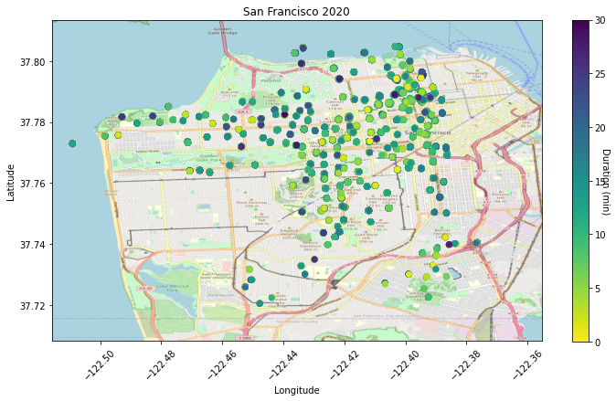

```python
m20_lat_long_sf = m2020_noDistOutl_4km_30min.query('(start_station_latitude > 37.7083)&(start_station_latitude <= 37.8133)&(start_station_longitude <=-122.3554)&(start_station_longitude >=-122.5158)')
#BBox = (-122.5158,   -122.3554,  37.7083, 37.8133)
fig, ax = plt.subplots(figsize = (12,12))
pos1 = ax.scatter(data=m20_lat_long_sf.dropna(), \
                           y='start_station_latitude', x='start_station_longitude', c='duration_min', cmap='viridis_r' )
plt.xticks(rotation=45)
ax.set_xlim(BBox[0],BBox[1])
ax.set_ylim(BBox[2],BBox[3])
ax.imshow(mymap, zorder=0, extent = BBox, aspect= 'equal')
cbar = plt.colorbar(pos1,ax=ax, shrink=0.54);
plt.xlabel('Longitude');
plt.ylabel('Latitude');
plt.title('San Francisco 2020');
cbar.set_label('Duration (min)', rotation=270);
```

Generally, we can note that trips are more concentrated in the city center in 2019, while more scattered in 2020.

In accordance to the plotted duration-series and from the violin plots for user-type, it looks like there are more trips with high duration in 2020, too, and these are more related to the outskirts of the city.

#### Distance

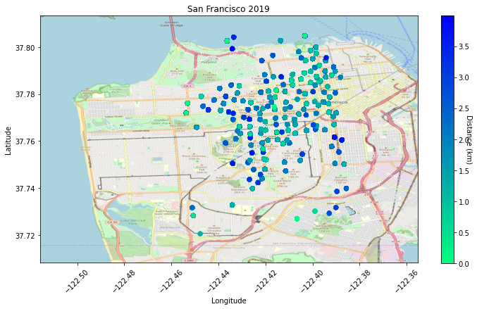

```python
m19_lat_long_sf = m2019_noDistOutl_4km_30min.query('(start_station_latitude > 37.7083)&(start_station_latitude <= 37.8133)&(start_station_longitude <=-122.3554)&(start_station_longitude >=-122.5158)')
BBox = (-122.5158,   -122.3554,  37.7083, 37.8133)
fig, ax = plt.subplots(figsize = (12,12))
pos1 = ax.scatter(data=m19_lat_long_sf.dropna(), \
                           y='start_station_latitude', x='start_station_longitude', c='distance_km', cmap='winter_r' )
mymap = plt.imread('sfmap.png')
plt.xticks(rotation=45)
ax.set_xlim(BBox[0],BBox[1])
ax.set_ylim(BBox[2],BBox[3])
pos = ax.imshow(mymap, zorder=0, extent = BBox, aspect= 'equal');
cbar = plt.colorbar(pos1,ax=ax, shrink=0.54);
plt.xlabel('Longitude');
plt.ylabel('Latitude');
plt.title('San Francisco 2019');
cbar.set_label('Distance (km)', rotation=270);
```

[figure not shown]

```python
m20_lat_long_sf = m2020_noDistOutl_4km_30min.query('(start_station_latitude > 37.7083)&(start_station_latitude <= 37.8133)&(start_station_longitude <=-122.3554)&(start_station_longitude >=-122.5158)')
#BBox = (-122.5158,   -122.3554,  37.7083, 37.8133)
fig, ax = plt.subplots(figsize = (12,12))
pos1 = ax.scatter(data=m20_lat_long_sf.dropna(), \
                           y='start_station_latitude', x='start_station_longitude', c='distance_km', cmap='winter_r' )
plt.xticks(rotation=45)
ax.set_xlim(BBox[0],BBox[1])
ax.set_ylim(BBox[2],BBox[3])
ax.imshow(mymap, zorder=0, extent = BBox, aspect= 'equal')
cbar = plt.colorbar(pos1,ax=ax, shrink=0.54);
plt.xlabel('Longitude');
plt.ylabel('Latitude');
plt.title('San Francisco 2020');
cbar.set_label('Distance (km)', rotation=270);
```

## Recap of Main Findings

We have seen that CoViD19 has had a major impact on the usage of the Bay-Wheel bike-sharing service. Most of our findings are interpretable as effects of the current pancemic situation on the way people use this bike-sharing service.

#### 1. Does the two months under analysis share the same trend of number of rides per day, distance, or duration?

Overall in July 2020, we have:

- less rides per day (especially on work days);
- longer distance;
- higher duration;
- more casual users (both, in absolute terms and w.r.t. members);
- less member usage.

#### 2. Is there a difference in station usage (frequency of use) in 2019 and in 2020?

Overall, the most stations registered a decrease of usage in july 2020, w.r.t. the same period in 2019.

We have found out that stations with the highest increase lay often near a park, while among those with sharp decrease there are public places and train stations.

Moreover, stations with a low number of bike rentals are more frequent in 2020 than in 2019, while stations have registered less rentals in 2020 in general.

#### 3. What is the relation between trip distance and average duration?

The relation between duration and distance is positive in both, July 2019 and in July 2020.

We have found a high-mass region of the graph, where this relation is clearly visible from the data.

However, we can see a way lower number of rides (also within the high-mass region) in 2020, w.r.t. 2019.

#### 4. Do 'casual' users an 'members' differ w.r.t. duration and distance?

Concerning both, duration and distance, we see a consistent increase in distribution mass for the two user types in 2020, w.r.t. 2019.

For the duration, this effect is more visible for the casual user-type.

#### 5. What is the relation between hour of day and day of week?

We can see how the pandemic have had an impact on when people travel.

The overall number of rides per hour is drastically reduced in 2020, w.r.t. 2019.

While in 2019 we can clearly see a 'commuting' pattern during the week (morning and evening), this patterns is not that clear in 2020.

Morning commuting seems to have not been taking place anymore in 2020, while a clearer pattern of 'free-time' rides appears in the evening hours or during the weekend. On Friday, Saturday and Sunday this change is more visible.

#### 6. Does Geospatial visualization give us more information on duraiton and distance?

Generally, we can note that trips are more concentrated in the city center in 2019, while more scattered in 2020.

In accordance to the plotted duration-series and from the Violin plots for user-type, it looks like there are more trips with high duration in 2020, too, and these are more related to the outskirts of the city.